# Web Scraping das ações listadas na Nasdaq usando o R

# Web Scraping em R

Primeiro, com a lista que obtivemos anteriormente com o nome de todos os papéis negociados nos EUA, vamos verificar qual deles estão disnponíveis na **NASDAQ**. O site que vamos utilizar para obter as informações é o **Google Finanças**, já que se mostra uma fonte confiável para os dados.

Para essa análise experimental, vamos utilizar um pequeno grupo de papéis relacionados ao ramo de tecnologia. Serão eles: Amazon (AMZN), Microsoft (MSFT), Apple (AAPL), Intel (INTC), Netflix (NFLX), Facebook (FB) e Alphabet (GOOG).

Todos os códigos estarão comentados para um maior entendimento do leitor.

```r
j <- 1 #definindo um index de início
working_list <- data.frame("ticker"=c()) #criando um data frame para armazenar
                                         #os papeis ativos na NASDAQ.

for(i in ticker_names$ticker){ #criando um for para acessar cada link e
                               #verificar se o status é 200, ou seja
                               #existe e pertence a NASDAQ.
  uastring <- "Mozilla/5.0 (Windows NT 6.1) AppleWebKit/537.36 (KHTML, like Gecko) Chrome/41.0.2228.0 Safari/537.36" #tentando imitar um acesso comum na página
                                                                                                                     #desejada, a fim de evitar ter o ip bloquado por
                                                                                                                     #ser um robo.
  urls <- paste0("https://www.google.com/finance/quote/",i,":NASDAQ")
  page <- session(urls, user_agent(uastring))

  if(page$response$status_code!=200){
    Sys.sleep(60) #caso o status seja diferente de 200 que é o esperado, espera 60 segundos para fazer uma nova requisicao
  }

  nome <- page %>% #pegando o nome de cada papel a fim de validar se pertence ou não a nasdaq
    html_nodes(".kHAtIb") %>%
    html_text() %>%  as.data.frame()

  if(length(row.names(nome))!=0){ #caso o link exista, o papel é salvo como acao da nasdaq
    working_list[j,"ticker"] <- i
    j <- j+1
    print(i)
  }

}

write.csv2(working_list,"working_tickers.csv") #por fim, escrevendo um csv com essas informacoes, para utilizarmos mais tarde caso necessario
```

## Realizando o scrap

Agora, vamos criar a função que obtem as informações necessárias para a nossa análise, como: Nome do papel, nome da empresa, preço do papel no momento da coleta dos dados e a hora que essa requisição foi realizada.

Antes de mostrar o código, vamos fazer uma breve explicação de como a função deve ser utilizada e quais são os seus parâmetros, outputs e questões para melhoramento.

Primeiro, devemos definir os parâmetros para a função **nasdaqg**, que são três:

```
     1. Papeis - lista com as siglas de todos os papéis que serão monitorados
     posteriormente

     2. Intervalo - intervalo em minutos para cada requisição (se Intervalo=30,
     novos dados serão captados a cada 30 minutos, por exemplo)

     3. Tempo - quantidade de horas que o programa irá rodar, contando da hora
     de inicialização (se Tempo=5, o programa irá rodar por 5 horas, por exemplo)
```

Como a NASDAQ funciona das 10h30 até 17h00, horário de brasilia, o programa tem um argumento condicional que para a execução do mesmo caso ele esteja operando fora do horário de funcionamento, já que nesses horários as movimentações estão paradas. Claro que, caso necessário essa funcionalidade pode ser alterada.

Assim, depois de realizar todas as requisições, podemos exportar nossos dados para um arquivo CSV, que será nomeado como **nasdaq-DATA**, ou seja, esse nome irá ser atualizado para cada dia que o programa for executado, a fim de descentralizar os dados e evitar qualquer possível eventualidade de impactar negativamente a nossa análise.

```r
#criando a função para conseguir os dados necessários
nasdaqg <- function(papeis, intervalo, tempo){

#o horário de funcionamento da NASDAQ é 10h30 até 17h30, horário de brasilia
#por isso, uma mensagem de erro aparece caso o programa seja executado
#fora desse horário.
  if(Sys.time() > 17:00 || Sys.time() < 10:30){print("Nasdaq Fechada, horário de funcionamento entre 10h30 e 17h00, horário de brasília.") & stop("Nasdaq Fechada, horário de funcionamento entre 10h30 e 17h00, horário de brasília.")
    }

  tempo_seg <- tempo*60*60 #para padronizar a execução do programa, todos os intervalos de tempo são convertidos para segundos.

  intervalo_seg <- intervalo*60 #para padronizar a execução do programa, todos os intervalos de tempo são convertidos para segundos.

  ate <- (tempo_seg/intervalo_seg) #definicao de quando a execução do while loop irá encerrar

  #definindo um user agent para imitar o comportamento de
  #um navegador comum, a fim de não receber um banimento por ip,
  #visto o alto número de requisições realizadas no servidor

  uastring <- "Mozilla/5.0 (Windows NT 6.1) AppleWebKit/537.36 (KHTML, like Gecko) Chrome/41.0.2228.0 Safari/537.36"

  url_base <- "https://www.google.com/finance/quote/" #definindo a url que será o padrão para as demais urls
  urls <- paste0(url_base,papeis,":NASDAQ") #criando todos os links baseados na url padão e nos papeis inseridos na função
  nasdaq <- data.frame("ticker"=c(),"nome"=c(),"valor"=c(),"data"=c()) #finalmente vamos começar a obter as informações
  t <- 1
  j <- 1
  while(t<ate){  #carregando a página html

    for(i in urls){

      page <- session(i, user_agent(uastring))

      #pegando o ticker (sigla)
      nasdaq[j,"ticker"] <- page %>%
        html_nodes(".GLlpnb") %>%
        html_text() %>%  as.data.frame() %>%
        str_replace("(?s) .*", "")

      #pegando o nome da empresa
      nasdaq[j,"nome"] <- page %>%
        html_nodes(".kHAtIb") %>%
        html_text() %>%  as.data.frame()

      #pegando o preco da acao
      nasdaq[j,"preco"] <- page %>%
        html_nodes(".fxKbKc") %>%
        html_text() %>% as.data.frame() %>% slice(1)

      #pegando o horário da requisicao
      nasdaq[j,"horario"] <- page %>%
        html_nodes(".ygUjEc") %>%
        html_text() %>% str_sub(start=8, end=24) %>% as.data.frame() %>% slice(2)

      j <- j+1

      nasdaq <- nasdaq[order(nasdaq[,'ticker']), ]

      write_csv2(nasdaq, paste0("nasdaq-",Sys.Date(),".csv")) #exportando esses dados para um CSV
    }

    Sys.sleep(intervalo_seg) #tempo de intervalo definido para cada requisicao

    t <- t+1

  }

}
```

## Considerações e feedback

OBS: Algumas alterações foram realizadas para acomodar os últimos feedbacks:

```
  1. O arquivo não reescreve no próximo dia, ou seja,
     a cada dia um novo arquivo é gerado, evitando possíveis
     perdas de dados.

  2. O site de onde as informações mudou para o Google Finaças, já
     que esse se mostrou uma fonte mais robusta e confiável para os dados.

  3. Caso a função seja executada fora do período de funcionamento da NASDAQ
     o programa retonará uma mensagem de erro informando que as ações não
     estão sendo movimentadas naquele horário.
```

# Análise exploratória

Agora, vamos plotar alguns gráficos que podem ajudar na tomada de decisão. Para essa análise, vamos utilizar os papéis referentes às empresas: Google, Facebook e Amazon. Foram utilizados dados diários e retroativos, desde 2011, já que nossa base de dados com um intervalo de monitoramento menor ainda não está robusta o suficiente para ser utilizada.

## Google

[interactive chart not shown]

## Facebook

[interactive chart not shown]

## Amazon

[interactive chart not shown]

Uma outra opção ainda, é padronizar os dados, ou seja, diminuir a media e dividir pelo desvio padrão, a fim de tornar o crescimento entre cada empresa comparável e também mostrar se o valor das ações está abaixo ou acima da média histórica, além de comparar o crescimento dessas empresas ao longo do tempo, agora, em uma escala padronizada, o que nos possibilita fazer uma análise mais adequada.

## Dados padronizados

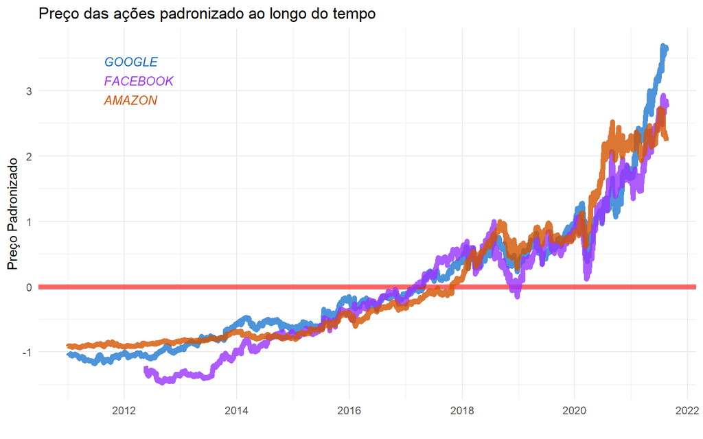

**A covariável preço se refere ao preço de fechamento dessa ação no dia em questão**

Como podemos observar, existe um crescimento positivo no valor dessas ações ao longo do tempo. Além disso, outro ponto a se destacar é o ritmo de valorização das cotas, que é muito semelhante entre as empresas. Por fim, notamos que, a partir de meados de 2020, o ritmo de valorização dos papeis aumentou, isso, poderia estar relacionado com o surgimento da pandemia e com o preparo dessas empresas para um ambiente de mudanças, como o trabalho home office e o maior consumo de midias digitais, porém, isso é apenas uma hipótese.

## Distribuição dos preços das ações

Para finalizar nossa análise exploratória, vamos plotar as densidades dos preços de cada uma das ações analisadas, para entender melhor qual o seu comportamento, e a partir disso, tentar realizar alguma inferência futura.

### Google

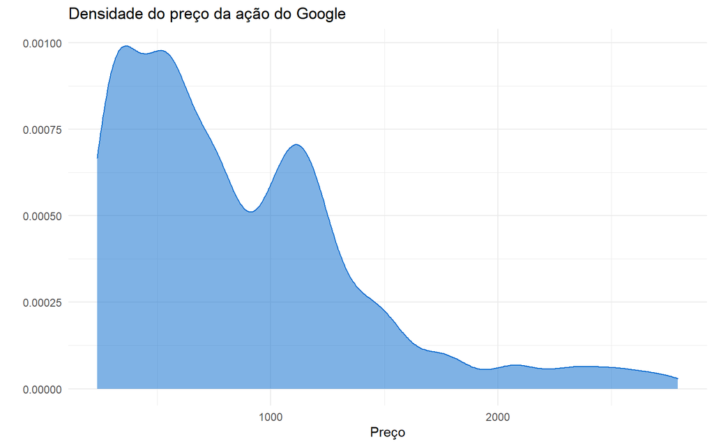

### Facebook

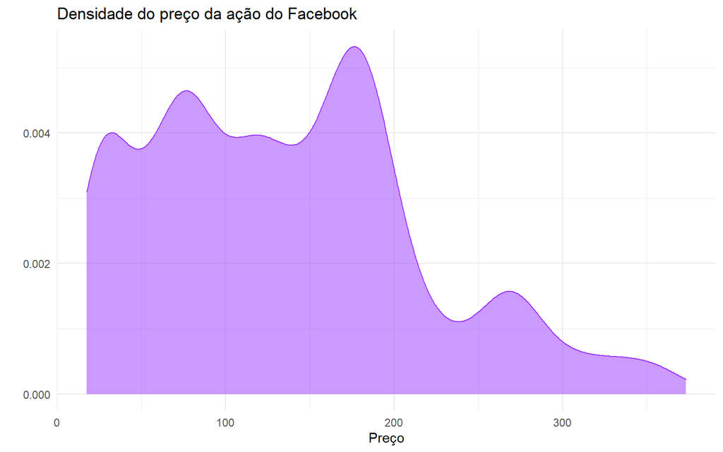

### Amazon

[figure not shown]

## Estudos futuros

Como sugestão para estudos futuros, fica a possibilidade da implementação de modelos de regressão para modelar a média e a variância, series temporais, clusterização e até mesmo modelos sofisticados de machine learning, caso o leitor julgue necessário. Por fim, baseado nessas inferências, poderiamos tomar decisões mais acertivas com relações ao posicionamento de mercado desejado.

# Web Scraping em Python

Para aqueles interessados na linguagem Python, fica um código que realiza a mesma função do apresentado acima, porém no ambiente Python, com a utilização dos pacotes **requests** e **BeautifulSoup**. Métodos mais avançados de raspagem de dados como **Scrapy** e **Splash** podem ser utilizados. O último, recomendado para sites dinâmicos (JavaScript). Lembrando que, esse código é apenas um ponta pé inicial e pode ser melhor desenvolvido pelo leitor.

```python
import requests
from bs4 import BeautifulSoup as bs
import time
import pandas as pd
import numpy
from datetime import date


urls=["https://www.google.com/finance/quote/GOOG:NASDAQ", #coloque aqui as urls dos papeis que você deseja monitorar
     "https://www.google.com/finance/quote/COKE:NASDAQ",
     "https://www.google.com/finance/quote/AAPL:NASDAQ",
     "https://www.google.com/finance/quote/TSLA:NASDAQ",
     "https://www.google.com/finance/quote/AMD:NASDAQ",
     "https://www.google.com/finance/quote/NFLX:NASDAQ",
     "https://www.google.com/finance/quote/NVDA:NASDAQ"]

preco=[]
nome_empresa=[]
ticker=[]
dia=[]
mes=[]
horario=[]
fuso=[]
t=1
tempo=3 #coloque aqui o a quantidade de horas que gostaria de rodar o programa
intervalo=1 #coloque aqui o intervalo em minutos que gostaria de realizar a consulta dos papeis escolhidos - refresh rate
tempo_seg = tempo*60*60
intervalo_seg = intervalo*60
ate = (tempo_seg/intervalo_seg)
data_run=date.today().strftime("%d-%b-%Y")

while t<ate:

    for i in urls:
        page = requests.get(i)
        soup = bs(page.content, 'html.parser')
        preco.append(soup.find("div", {"class": "YMlKec fxKbKc"}).get_text().replace('$', ''))
        nome_empresa.append(soup.find("h1", {"class": "kHAtIb"}).get_text())
        ticker.append(soup.find("h2", {"class": "GLlpnb"}).get_text().split(" ", 1)[0])
        hora=soup.find("div", {"class": "ygUjEc#text"}).get_text()
        t=t+1
        data = {'ticker': ticker, 'nome_empresa': nome_empresa,'preco': preco,
                'hora': hora}
        df=pd.DataFrame(data).sort_values(by="ticker")
        print(df)
        df.to_csv("/beautiful_soup/"+"nasdaq-"+str(data_run)+".csv", sep=";", decimal=",", index=0)
    time.sleep(intervalo_seg)
```